# Introduction

In this topic modeling exercise, we will be looking at clinical notes and trying to extract meaningful information about the underlying causes of a particular medical condition. My approach to this was to cluster the clinical notes into different categories using Latent Dirichlet Allocation to see if the categories gave any meaningful keywords and whether they referred to a particular medical condition.

```python
import numpy as np
import pandas as pd

import gensim
import gensim.corpora as corpora
from gensim.utils import simple_preprocess
from gensim.models import CoherenceModel

import spacy
from spacy.lemmatizer import Lemmatizer
from spacy.lang.en.stop_words import STOP_WORDS
import spacy.cli
spacy.cli.download("en_core_web_md")
```

```
✔ Download and installation successful
You can now load the model via spacy.load('en_core_web_md')
```

### Download files and convert into a DataFrame

```python
import os

#list the files
targetdir = './training_20180910'
filelist = os.listdir(targetdir)

#read them into a list(ignoring the .ann files for now) and then into a pandas df
notes_list = [open(targetdir + '/' + file).read() for file in filelist if file.endswith(".txt")]
df = pd.DataFrame(notes_list, columns = ['ClinicalNotes'])
```

```python
import re

#Remove punctuation and convert to lowercase
df['ClinicalNotesPreprocessed'] = df['ClinicalNotes'].map(lambda x: re.sub('[,\*.!?]', '', x))
df['ClinicalNotesPreprocessed'] = df['ClinicalNotesPreprocessed'].map(lambda x: x.lower())

df.head()
```

|  | ClinicalNotes | ClinicalNotesPreprocessed |
| --- | --- | --- |
| 0 | Admission Date: [**2115-2-22**] ... | admission date: [2115-2-22] disc... |
| 1 | Admission Date: [**2174-4-18**] ... | admission date: [2174-4-18] disc... |
| 2 | Admission Date: [**2107-1-17**] ... | admission date: [2107-1-17] disc... |
| 3 | Admission Date: [**2114-12-24**] ... | admission date: [2114-12-24] dis... |
| 4 | Admission Date: [**2144-1-20**] ... | admission date: [2144-1-20] disc... |

### Visualization

Next we will look at a word cloud of some sample clinical notes to get an idea for what kind of preprocessing we will need to do.

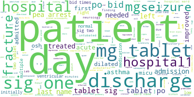

```python
# Import the wordcloud library
from wordcloud import WordCloud

long_string = list(df.ClinicalNotesPreprocessed.values)[0]

# Create a WordCloud object
wordcloud = WordCloud(background_color="white", max_words=1000, contour_width=3, contour_color='steelblue')

# Generate a word cloud
wordcloud.generate(long_string)

# Visualize the word cloud
wordcloud.to_image()
```

### Preparing the Text for Latent Dirichlet Allocation(LDA)

We need to do the standard preprocessing, removing stopwords, tokenizing, and lemmatizing the text. Additionally we're also going to consider bigrams and trigrams. I decided to add more stopwords based on the medical context of this dataset.

```python
import nltk
nltk.download('stopwords')
from nltk.corpus import stopwords

stop_words = stopwords.words('english')
stop_words.extend(['patient', 'discharge', 'daily', 'hospital', 'day', 'name', 'blood',
                   'history', 'tablet', 'leave','left', 'pain', 'last', 'right','see',
                   'give','course','date','low','status','normal','show','start','continue'
                  'admission','follow','medication'])

def sent_to_words(sentences):
    for sentence in sentences:
        # deacc=True removes punctuations
        yield(gensim.utils.simple_preprocess(str(sentence), deacc=True))

def remove_stopwords(texts):
    return [[word for word in simple_preprocess(str(doc))
             if word not in stop_words] for doc in texts]

def lemmatization(texts, allowed_postags=['NOUN', 'ADJ', 'VERB', 'ADV']):
    """https://spacy.io/api/annotation"""
    texts_out = []
    for sent in texts:
        doc = nlp(" ".join(sent))
        texts_out.append([token.lemma_ for token in doc if token.pos_ in allowed_postags])
    return texts_out


data = df.ClinicalNotesPreprocessed.values.tolist()
data_words = list(sent_to_words(data))

# remove stop words
data_words = remove_stopwords(data_words)

# Build the bigram and trigram models
bigram = gensim.models.Phrases(data_words, min_count=5, threshold=100) # higher threshold fewer phrases.
trigram = gensim.models.Phrases(bigram[data_words], threshold=100)

# Faster way to get a sentence clubbed as a trigram/bigram
bigram_mod = gensim.models.phrases.Phraser(bigram)
trigram_mod = gensim.models.phrases.Phraser(trigram)


def make_bigrams(texts):
    return [bigram_mod[doc] for doc in texts]

def make_trigrams(texts):
    return [trigram_mod[bigram_mod[doc]] for doc in texts]


# Form Bigrams and trigrams
data_words = make_bigrams(data_words)
data_words = make_trigrams(data_words)

# lemmatize
nlp = spacy.load('en_core_web_sm', disable=['parser', 'ner'])

# Do lemmatization keeping only noun, adj, vb, adv
data_words = lemmatization(data_words, allowed_postags=['NOUN', 'ADJ', 'VERB', 'ADV'])



print(data_words[:1][0][5:30])
```

```
['major_surgical_invasive_procedure', 'intubation', 'removal', 'place', 'cvl', 'placement', 'pmh', 'signifciant', 'dilated_cardiomyopathy', 'aicd', 'asthma', 'admit', 'dyspnea', 'admit', 'micu', 'initially', 'present', 'receive', 'azithromycin', 'sc', 'become', 'confused', 'subsequently', 'episode',…
```

```python
# Create Dictionary
id2word = corpora.Dictionary(data_words)

# Create Corpus
texts = data_words

# Term Document Frequency
corpus = [id2word.doc2bow(text) for text in texts]

# View
print(corpus[:1][0][:100])
```

```
[(0, 2), (1, 1), (2, 1), (3, 1), (4, 2), (5, 3), (6, 1), (7, 6), (8, 1), (9, 2), (10, 1), (11, 1), (12, 4), (13, 1), (14, 6), (15, 2), (16, 1), (17, 1), (18, 1), (19, 2), (20, 2), (21, 2), (22, 2), (23, 1), (24, 1), (25, 1), (26, 6), (27, 2), (28, 1), (29, 1), (30, 4), (31, 1), (32, 1), (33, 1), (34…
```

```python
from pprint import pprint

# number of topics
num_topics = 5

# Build LDA model
lda_model = gensim.models.LdaMulticore(corpus=corpus,
                                       id2word=id2word,
                                       num_topics=num_topics)

# Print the Keyword in the topics
pprint(lda_model.print_topics())
doc_lda = lda_model[corpus]
```

```
[(0,
  '0.008*"medication" + 0.007*"time" + 0.006*"pm" + 0.005*"show" + '
  '0.005*"capsule" + 0.005*"continue" + 0.005*"start" + 0.005*"transfer" + '
  '0.005*"give" + 0.005*"prior"'),
 (1,
  '0.006*"give" + 0.006*"admission" + 0.005*"continue" + 0.005*"need" + '
  '0.005*"pm" + 0.005*"chest" + 0.004*"due" + 0.004*"well" + 0.004*"negative" '
  '+ 0.004*"time"'),
 (2,
  '0.007*"continue" + 0.006*"pm" + 0.005*"medication" + 0.005*"start" + '
  '0.004*"capsule" + 0.004*"give" + 0.004*"chest" + 0.004*"time" + '
  '0.004*"also" + 0.004*"change"'),
 (3,
  '0.006*"need" + 0.006*"give" + 0.005*"also" + 0.005*"start" + 0.005*"pm" + '
  '0.005*"medication" + 0.005*"take" + 0.005*"week" + 0.005*"note" + '
  '0.005*"likely"'),
 (4,
  '0.006*"give" + 0.006*"time" + 0.005*"continue" + 0.005*"start" + '
  '0.005*"negative" + 0.005*"increase" + 0.004*"also" + 0.004*"transfer" + '
  '0.004*"take" + 0.004*"change"')]
```

```python
# Plotting tools
import pyLDAvis
import pyLDAvis.gensim_models
import matplotlib.pyplot as plt
%matplotlib inline

# Enable logging for gensim
import logging
logging.basicConfig(format='%(asctime)s : %(levelname)s : %(message)s', level=logging.ERROR)

import warnings
warnings.filterwarnings("ignore",category=DeprecationWarning)
```

### Evaluating the Sample Model

```python
# Compute Perplexity
print('\nPerplexity: ', lda_model.log_perplexity(corpus))  # a measure of how good the model is. lower the better.

# Compute Coherence Score
coherence_model_lda = CoherenceModel(model=lda_model, texts=texts, dictionary=id2word, coherence='c_v')
coherence_lda = coherence_model_lda.get_coherence()
print('\nCoherence Score: ', coherence_lda)
```

```
Perplexity:  -8.126424575424718

Coherence Score:  0.31314381677441133
```

### Visualize the LDA model

Generally, a good model will have moderately-sized circles scattered throughout the chart with minimal overlap. On the right we can see the 30 most frequent terms. Setting lambda = 1 and clicking on the bubble will show how the frequency of the terms in that topic compare to the overall term frequencies. As we scale lambda to 0, clicking on a bubble will show the most relevant terms for that particular topic.

```python
# Visualize the topics
pyLDAvis.enable_notebook()
vis = pyLDAvis.gensim_models.prepare(lda_model, corpus, id2word)
vis
```

[interactive chart not shown]

### Testing Different Numbers of Topics

```python
#Returns the list of coherence values for the different values of num_topics

def compute_coherence_values(dictionary, corpus, texts, limit, start=2, step=3):
    coherence_values = []
    model_list = []
    for num_topics in range(start, limit, step):
        model = gensim.models.LdaMulticore(corpus=corpus,
                                       id2word=id2word,
                                       num_topics=num_topics)
        model_list.append(model)
        coherencemodel = CoherenceModel(model=model, texts=texts, dictionary=dictionary, coherence='c_v')
        coherence_values.append(coherencemodel.get_coherence())


    return model_list, coherence_values
```

```python
#This part will take a while.  If you want you can include a print command in the function to see the progress.
model_list, coherence_values = compute_coherence_values(dictionary=id2word, corpus=corpus, texts=texts, start=2, limit=40, step=2)
```

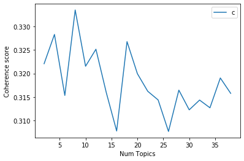

```python
# Show graph
limit=40; start=2; step=2;
x = range(start, limit, step)
plt.plot(x, coherence_values)
plt.xlabel("Num Topics")
plt.ylabel("Coherence score")
plt.legend(("coherence_values"), loc='best')
plt.show()
```

```python
# Print the coherence scores
for m, cv in zip(x, coherence_values):
    print("Num Topics =", m, " has Coherence Value of", round(cv, 4))
```

```
Num Topics = 2  has Coherence Value of 0.3221
Num Topics = 4  has Coherence Value of 0.3283
Num Topics = 6  has Coherence Value of 0.3153
Num Topics = 8  has Coherence Value of 0.3335
Num Topics = 10  has Coherence Value of 0.3215
Num Topics = 12  has Coherence Value of 0.3251
Num Topics = 14  has Coherence Value of 0.3159
Num Topics = 16  has Coherence Value of 0.3078
Num Topics = 18  has Coherence Value of 0.3267
Num Topics = 20  has Coherence Value of 0.3199
Num Topics = 22  has Coherence Value of 0.3162
Num Topics = 24  has Coherence Value of 0.3144
Num Topics = 26  has Coherence Value of 0.3077
Num Topics = 28  has Coherence Value of 0.3165
Num Topics = 30  has Coherence Value of 0.3123
Num Topics = 32  has Coherence Value of 0.3144
Num Topics = 34  has Coherence Value of 0.3127
Num Topics = 36  has Coherence Value of 0.319
Num Topics = 38  has Coherence Value of 0.3158
```

We see that we can actually get a slightly higher coherence value if we choose 8 topics instead of 5.

### Categorizing Each Document

For each document we list the topic that it was classified in and the percentage that category makes up of the document.

```python
def format_topics_sentences(ldamodel=lda_model, corpus=corpus, texts=data):
    # Init output
    sent_topics_df = pd.DataFrame()

    # Get main topic in each document
    for i, row in enumerate(ldamodel[corpus]):
        row = sorted(row, key=lambda x: (x[1]), reverse=True)
        # Get the Dominant topic, Percent Contribution and Keywords for each document
        for j, (topic_num, prop_topic) in enumerate(row):
            if j == 0:  # => dominant topic
                wp = ldamodel.show_topic(topic_num)
                topic_keywords = ", ".join([word for word, prop in wp])
                sent_topics_df = sent_topics_df.append(pd.Series([int(topic_num), round(prop_topic,4), topic_keywords]), ignore_index=True)
            else:
                break
    sent_topics_df.columns = ['Dominant_Topic', 'Perc_Contribution', 'Topic_Keywords']

    # Add original text to the end of the output
    contents = pd.Series(texts)
    sent_topics_df = pd.concat([sent_topics_df, contents], axis=1)
    return(sent_topics_df)


df_topic_sents_keywords = format_topics_sentences(ldamodel=lda_model, corpus=corpus, texts=list(df.ClinicalNotes.values))

# Format
df_dominant_topic = df_topic_sents_keywords.reset_index()
df_dominant_topic.columns = ['Document_No', 'Dominant_Topic', 'Topic_Perc_Contrib', 'Keywords', 'Text']

# Show
df_dominant_topic.head(10)
```

|  | Document_No | Dominant_Topic | Topic_Perc_Contrib | Keywords | Text |
| --- | --- | --- | --- | --- | --- |
| 0 | 0 | 0.0 | 0.6726 | medication, time, pm, show, capsule, continue,... | Admission Date: [**2115-2-22**] ... |
| 1 | 1 | 0.0 | 0.9936 | medication, time, pm, show, capsule, continue,... | Admission Date: [**2174-4-18**] ... |
| 2 | 2 | 0.0 | 0.9618 | medication, time, pm, show, capsule, continue,... | Admission Date: [**2107-1-17**] ... |
| 3 | 3 | 1.0 | 0.4993 | give, admission, continue, need, pm, chest, du... | Admission Date: [**2114-12-24**] ... |
| 4 | 4 | 2.0 | 0.4982 | continue, pm, medication, start, capsule, give... | Admission Date: [**2144-1-20**] ... |
| 5 | 5 | 0.0 | 0.6661 | medication, time, pm, show, capsule, continue,... | Admission Date: [**2125-10-17**] ... |
| 6 | 6 | 3.0 | 0.6148 | need, give, also, start, pm, medication, take,... | Admission Date: [**2108-4-16**] ... |
| 7 | 7 | 0.0 | 0.8293 | medication, time, pm, show, capsule, continue,... | Admission Date: [**2181-7-12**] ... |
| 8 | 8 | 0.0 | 0.9173 | medication, time, pm, show, capsule, continue,... | Admission Date: [**2149-2-21**] ... |
| 9 | 9 | 3.0 | 0.7522 | need, give, also, start, pm, medication, take,... | Admission Date: [**2102-5-31**] Dischar... |

### Display the Most Representative Medical Record for each Topic

```python
# Group top 5 sentences under each topic
sent_topics_sorteddf = pd.DataFrame()

sent_topics_outdf_grpd = df_topic_sents_keywords.groupby('Dominant_Topic')

for i, grp in sent_topics_outdf_grpd:
    sent_topics_sorteddf = pd.concat([sent_topics_sorteddf,
                                             grp.sort_values(['Perc_Contribution'], ascending=[0]).head(1)],
                                            axis=0)

# Reset Index
sent_topics_sorteddf.reset_index(drop=True, inplace=True)

# Format
sent_topics_sorteddf.columns = ['Topic_Num', "Topic_Percent_Contribution", "Keywords", "Text"]

# Show
sent_topics_sorteddf.head(7)
```

|  | Topic_Num | Topic_Percent_Contribution | Keywords | Text |
| --- | --- | --- | --- | --- |
| 0 | 0.0 | 0.9982 | medication, time, pm, show, capsule, continue,... | Admission Date: [**2198-4-30**] ... |
| 1 | 1.0 | 0.9920 | give, admission, continue, need, pm, chest, du... | Admission Date: [**2191-6-24**] ... |
| 2 | 2.0 | 0.9962 | continue, pm, medication, start, capsule, give... | Admission Date: [**2152-6-19**] ... |
| 3 | 3.0 | 0.9955 | need, give, also, start, pm, medication, take,... | Admission Date: [**2196-3-4**] D... |
| 4 | 4.0 | 0.9925 | give, time, continue, start, negative, increas... | Admission Date: [**2121-9-30**] ... |

### Topic Distribution

We will examine a table that will shows the key words for each category and displays the number of documents in that category as well as the percentage of documents it represents.

```python
#Filters by topic and keyword and counts the documents in each topic category
df_dominant_topics = df_topic_sents_keywords[['Dominant_Topic', 'Topic_Keywords']].groupby(['Dominant_Topic', 'Topic_Keywords'])['Topic_Keywords'].count()
df_dominant_topics = df_dominant_topics.reset_index(name='Num_Documents')

#Computes the percentages of documents in each topic category
df_dominant_topics['Percentage_of_Documents'] = ((df_dominant_topics['Num_Documents'])/(df_dominant_topics['Num_Documents'].sum()))


# Show
df_dominant_topics
```

|  | Dominant_Topic | Topic_Keywords | Num_Documents | Percentage_of_Documents |
| --- | --- | --- | --- | --- |
| 0 | 0.0 | medication, time, pm, show, capsule, continue,... | 167 | 0.551155 |
| 1 | 1.0 | give, admission, continue, need, pm, chest, du... | 41 | 0.135314 |
| 2 | 2.0 | continue, pm, medication, start, capsule, give... | 35 | 0.115512 |
| 3 | 3.0 | need, give, also, start, pm, medication, take,... | 44 | 0.145215 |
| 4 | 4.0 | give, time, continue, start, negative, increas... | 16 | 0.052805 |

### Future Steps

We saw a sample breakdown into topics using LDA. There are still more avenues to pursue along these lines. For example we can still tune more hyperparameters and we can still tweak the stopwords, parameters for the n-grams, and testing out lemmatizing different parts of speech. Furthermore, we could use Mallet's implementation of LDA instead of Gensim, which is expected to provide better Coherence values.